# act_report

## Act Report: WeRateDog Project

### What is WeRateDogs Project's about?

WeRateDogs is a platform where people can rate thier dogs. they have on twitter over 8M followers. So we are trying in this project to find how to understand the users they participate in the account for example: What is the the most frequent dog's name, or what is the source that users rate dogs such as iphone...etc

I downloaded the Twitter data for the WeRateDogs website. The final dataset contained 1899 tweets.

#### After I cleaned my data it’s time to visulize it and have some insights about our data.

```python
from IPython.display import Image
```

### First, What is the most popular name?

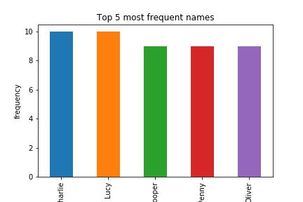

```python
Image(filename='names.jpg')
```

### Second, What is the most popular Source?

[figure not shown]

```python
Image(filename='source.jpg')
```

> As we can see, my visulaization shows that the most popular source was twitter from iphone with high different between it and the second top source. So it means that most users use an iphone to share thier ratings.

### Last, What is the most popular dog type?

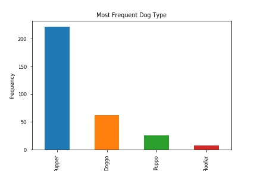

```python
Image(filename='type.jpg')
```

> As we can see, my visulaization shows thst the most popular dog type was
> 1. Pupper
> 2. Doggo
> 3. Puppo
> 4. Floofer  
>    So pupper is the most popular dog type the users have with a high difference between Pupper and other types.